# #ManyDaughters: Descriptive Statistics

Felix Holzmeister

2026-10-22

# Preamble

This `.Rmd` file produces descriptive summary statistics for all variables that enter the preregistered analyses, along with several additional variables used to characterize the sample. The sections cover **(i)** individual-level characteristics, **(ii)** team-level characteristics, **(iii)** prior and posterior beliefs about the four hypotheses, **(iv)** peer evaluations of the submitted pre-analysis plans, **(v)** the research teams’ empirical results on the four hypotheses, **(vi)** the per-hypothesis and RT-level idiosyncrasy index, and **(vii)** the consistency between the RT-PAPs and the submitted analysis code. All descriptives are based on the research teams that completed the entire project; deviations from this sample are stated where they apply.

# Individual-level characteristics

This section describes the participating researchers as individuals: team composition, recruitment channel, gender, geographic location, primary research field, academic position, publication record, and self-rated experience. All counts and frequencies refer to individual researchers (rather than research teams).

**[Team composition]** Our sample comprises 230 individual researchers, organized in 127 research teams who completed all project stages: 103 teams consist of two members, and 24 teams include only one member.

**[Recruitment channels]** Of the researchers involved, 43 (18.7%) learned about the study via *Lab²* announcements, 24 (10.4%) via *SOEP* announcements, 27 (11.7%) through one of the research coordinators, and 74 (32.2%) through their research team member. 62 (27%) researchers reported having learned about the study through other channels.

**[Gender]** Of the 230 individual researchers involved as research team members, 77 (33.5%) identify as female and 151 (65.7%) identify as male; 2 (0.9%) classify themselves as “other.”

**[Location]** The vast majority of participants are from Europe ($n$ = 194; 84.3%), followed by Northern America ($n$ = 17; 7.4%), Asia ($n$ = 13; 5.7%), Latin America ($n$ = 3; 1.3%), and Oceania ($n$ = 3; 1.3%).

**[Research field]** Most participants ($n$ = 148; 64.3%) report Economics as their primary field of research, followed by Sociology ($n$ = 40; 17.4%), Business Administration ($n$ = 14; 6.1%), Finance ($n$ = 11; 4.8%), Political Science ($n$ = 9; 3.9%), Psychology ($n$ = 4; 1.7%), and other fields ($n$ = 4; 1.7%).

**[Position]** Among the 230 researchers involved, 24 (10.4%) are full professors, 25 (10.9%) are associate professors, 54 (23.5%) are assistant professors, 77 (33.5%) are post-doctoral researchers, and 34 (14.8%) are PhD candidates. The remaining participants hold other positions within or beyond academia.

**[Publications]** Of the 230 individual researchers, 81 (35.2%) have published at least one article in a top-tier journal (_AJG 4*_ according to the *ABS* rating, or included in the *FT50* journal list). While 215 (93.5%) researchers have at least one publication employing empirical methods, only 50 (21.7%) have published work related to a study on the “daughters” hypothesis.

**[Experience]** The table below summarizes participants’ self-rated experience (rated on scales from 0 [“no experience”] to 10 [“extensive experience”]) in regression analysis, *Stata*, large datasets, and pre-analysis plans. Among the 230 researchers involved, 91 (39.6%) had previously participated in a meta-scientific crowd-science project, and 84 (36.5%) had used *SOEP* data before.

|  | *m* | *sd* | *min* | *q*<sub>25</sub> | *q*<sub>50</sub> | *q*<sub>75</sub> | *max* |
| --- | --- | --- | --- | --- | --- | --- | --- |
| Experience: Regression analysis | 8.93 | 1.18 | 5 | 8 | 9 | 10 | 10 |
| Experience: Analysis using Stata | 8.17 | 2.01 | 0 | 8 | 9 | 10 | 10 |
| Experience: Large datasets | 7.98 | 2.04 | 1 | 7 | 8 | 10 | 10 |
| Experience: Pre-analysis plans | 5.99 | 2.98 | 0 | 4 | 7 | 8 | 10 |

# Team-level characteristics

This section describes the research teams. The first paragraph summarizes team composition (size, seniority, field affiliation, top-tier publication record, and prior *SOEP* experience), using the team-level aggregations defined in PAP §2.2. The table that follows reports the teams’ self-reported effort (**+**), modeling approach (**§**), and aggregated experience (**#**).

**[Team composition]** Of the 160 research teams recruited into the project, 33 dropped out before completion (PAP §3), leaving 127 teams that completed all project stages and constitute our sample. 103 (81.1%) teams consist of two members; 24 (18.9%) teams include only one member. Of the participating teams, 41 (32.3%) included at least one senior researcher (full or associate professor), 95 (74.8%) had at least one member affiliated with economics or finance, 66 (52%) included a member with a top-tier publication, and 60 (47.2%) included a member experienced in using *SOEP* data.

**[Effort, approach, experience]** The table below presents team-level measures of research teams’ self-reported effort (**+**), their approach to developing the analytical model (**§**), and their self-rated experience (**#**). The number of iterations to computational reproducibility was tracked by the project coordinators; effort, hours spent, and the modeling-approach items were reported jointly by each team in the post-Stage 2 survey. Experience-related variables are derived from individual-level survey responses and aggregated to the team level using the maximum across team members; *“Experience: Analysis”* is the average of researchers’ reported experience with *(i)* regression analysis, *(ii)* *Stata*, and *(iii)* large datasets. Two teams (one per condition) reported more than 600 hours — far above the rest of the distribution — so the table additionally reports hours worked after excluding these two outliers.

|  | *m* | *sd* | *min* | *q*<sub>25</sub> | *q*<sub>50</sub> | *q*<sub>75</sub> | *max* |
| --- | --- | --- | --- | --- | --- | --- | --- |
| (+) Hours worked in stages 1 and 2 | 58.44 | 109.07 | 7.0 | 20.0 | 36.0 | 60.0 | 975.0 |
| (+) Hours worked, stages 1 and 2 (excl. 2 outliers) | 45.35 | 32.07 | 7.0 | 20.0 | 36.0 | 60.0 | 150.0 |
| (+) Effort in stages 1 and 2 (0-10) | 7.56 | 1.41 | 3.0 | 7.0 | 8.0 | 8.0 | 10.0 |
| (+) Reproducibility: No. iterations | 2.31 | 1.41 | 1.0 | 1.0 | 2.0 | 3.0 | 7.0 |
| (§) Literature search for theory (0-10) | 5.33 | 3.02 | 0.0 | 3.0 | 5.0 | 8.0 | 10.0 |
| (§) Simplest analyses possible (0-10) | 6.73 | 2.86 | 0.0 | 5.0 | 8.0 | 9.0 | 10.0 |
| (§) Multiple analyses considered (0-10) | 7.70 | 2.92 | 0.0 | 7.0 | 9.0 | 10.0 | 10.0 |
| (#) Experience: Analysis (0-10) | 8.98 | 1.03 | 5.7 | 8.3 | 9.3 | 10.0 | 10.0 |
| (#) Experience: Pre-analysis plans (0-10) | 7.02 | 2.55 | 0.0 | 6.0 | 8.0 | 9.0 | 10.0 |

**Note:** The *excl. 2 outliers* row omits the two research teams that reported more than 600 hours (one per condition; 765 and 975 hours), which lie far above the rest of the distribution; all other rows use the full sample.

# Prior and posterior beliefs

This section summarizes research teams’ beliefs about the likelihood (expressed as a 0-1 fraction) that RT Hypotheses 1 through 4 would be supported at the 5% significance level. Priors were elicited before Stage 1 (Survey #1) and posteriors after Stage 2 (Survey #2). The table reports descriptive statistics for the priors, the posteriors, and the within-team belief change (posterior minus prior), separately for each hypothesis.

|  | *m* | *sd* | *min* | *q*<sub>25</sub> | *q*<sub>50</sub> | *q*<sub>75</sub> | *max* |
| --- | --- | --- | --- | --- | --- | --- | --- |
| RT Hypothesis 1 |  |  |  |  |  |  |  |
| Stage 1 Belief | 0.63 | 0.22 | 0.05 | 0.51 | 0.70 | 0.80 | 1.00 |
| Stage 2 Belief | 0.46 | 0.31 | 0.00 | 0.20 | 0.44 | 0.71 | 1.00 |
| Change (S2 - S1) | −0.18 | 0.34 | −0.94 | −0.44 | −0.12 | 0.05 | 0.53 |
| RT Hypothesis 2 |  |  |  |  |  |  |  |
| Stage 1 Belief | 0.37 | 0.21 | 0.00 | 0.20 | 0.34 | 0.50 | 0.95 |
| Stage 2 Belief | 0.53 | 0.31 | 0.00 | 0.20 | 0.51 | 0.80 | 1.00 |
| Change (S2 - S1) | 0.16 | 0.34 | −0.89 | −0.05 | 0.14 | 0.40 | 0.95 |
| RT Hypothesis 3 |  |  |  |  |  |  |  |
| Stage 1 Belief | 0.36 | 0.24 | 0.00 | 0.20 | 0.32 | 0.51 | 0.95 |
| Stage 2 Belief | 0.33 | 0.29 | 0.00 | 0.10 | 0.20 | 0.52 | 0.95 |
| Change (S2 - S1) | −0.03 | 0.32 | −0.85 | −0.26 | 0.00 | 0.15 | 0.92 |
| RT Hypothesis 4 |  |  |  |  |  |  |  |
| Stage 1 Belief | 0.59 | 0.23 | 0.00 | 0.50 | 0.60 | 0.80 | 1.00 |
| Stage 2 Belief | 0.38 | 0.29 | 0.00 | 0.13 | 0.33 | 0.61 | 0.95 |
| Change (S2 - S1) | −0.22 | 0.32 | −1.00 | −0.48 | −0.20 | 0.00 | 0.65 |

The figure below shows the distributions underlying the table, by hypothesis (columns) and treatment condition (rows). Each dot is one research team’s reported belief; the thin gray lines connect a team’s prior (Survey #1) to its posterior (Survey #2). The violins outline the distribution of beliefs per condition and elicitation, and the horizontal bars mark the corresponding means. One single-member team did not reach the belief task in Survey #1 and therefore appears with its posterior beliefs only.

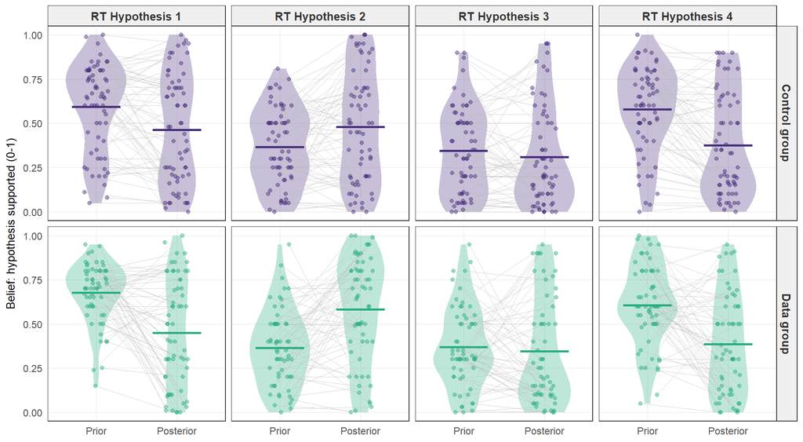

# Balance across treatment conditions

Research teams were randomized into the two conditions when they entered the project — before any team received data, and before the Survey #1 belief elicitation. The table below compares the two conditions on the team-level characteristics that enter the preregistered analyses as controls (PAP §2.2) and on the prior beliefs elicited in Survey #1, across the research teams that completed the project.

The $p$-values are **descriptive**: they summarize how far apart the two conditions happen to be on each characteristic in the realized sample, and no inference is drawn from them. They are unadjusted, and eleven comparisons are reported, so isolated values below conventional thresholds are expected even under perfectly balanced randomization.

|  | *n* | Control group | Data | Diff | *p* (descriptive) |
| --- | --- | --- | --- | --- | --- |
| Team characteristics |  |  |  |  |  |
| Team of two | 127 | 53 (80.3%) | 50 (82.0%) | +1.7 | 0.990 |
| Assoc./full professor | 127 | 24 (36.4%) | 17 (27.9%) | -8.5 | 0.405 |
| Economist | 127 | 50 (75.8%) | 45 (73.8%) | -2.0 | 0.958 |
| AJG 4*/FT50 publication | 127 | 36 (54.5%) | 30 (49.2%) | -5.4 | 0.669 |
| Experience: SOEP data | 127 | 34 (51.5%) | 26 (42.6%) | -8.9 | 0.409 |
| Experience: analysis (0-10) | 127 | 8.79 (1.15) | 9.17 (0.84) | +0.38 | 0.036 |
| Experience: PAPs (0-10) | 127 | 6.86 (2.38) | 7.18 (2.74) | +0.32 | 0.487 |
| Prior beliefs (Survey #1) |  |  |  |  |  |
| RT Hypothesis 1 | 126 | 0.593 (0.248) | 0.678 (0.170) | +0.085 | 0.028 |
| RT Hypothesis 2 | 126 | 0.367 (0.215) | 0.364 (0.215) | -0.003 | 0.928 |
| RT Hypothesis 3 | 126 | 0.345 (0.243) | 0.370 (0.229) | +0.025 | 0.549 |
| RT Hypothesis 4 | 126 | 0.579 (0.241) | 0.606 (0.227) | +0.027 | 0.519 |

**Notes:** Research teams that completed the project. Binary characteristics report the number and share of teams in the stated category, with the difference in percentage points and a chi-squared test with continuity correction; the remaining rows report the group mean with the standard deviation in parentheses, with the difference in means in the units of the variable and a two-sample *t*-test (equal variances). Beliefs are the probabilities elicited in Survey #1, expressed as 0-1 fractions; one team did not reach the belief task in that survey, so the belief rows rest on one team fewer. All *p*-values are descriptive and unadjusted across the eleven comparisons shown.

# Peer evaluations

This section summarizes the peer evaluations of the submitted RT-PAPs. Each completing RT rated ten anonymized RT-PAPs (five per group, excluding its own) on **(i)** the reasonableness of the proposed analysis and **(ii)** the informativeness of the pre-analysis plan, both on a 0-10 scale, separately for each of the four hypotheses; the per-rating PAP quality is the mean of the two scores (PAP §2.1).

The table reports descriptive statistics for the raw scores and for the corresponding rater-demeaned scores (each rating minus the rater’s mean rating for that hypothesis), the latter implicitly netting out rater fixed effects. Each statistic is computed across the per-(rated team $\times$ hypothesis) *mean* ratings — the individual ratings are first averaged over the (approximately ten) raters of each PAP — so the reported standard deviations are *between-PAP* standard deviations of the mean rating, smaller than the standard deviations of the individual ratings by roughly $\sqrt{10}$ (the individual-rating SDs are reported in the table note below). Demeaning here is for descriptive comparability only; the preregistered tests in PAP §3.2.2 use the individual ratings together with rater fixed effects.

|  | *m* | *sd* | *min* | *q*<sub>25</sub> | *q*<sub>50</sub> | *q*<sub>75</sub> | *max* |
| --- | --- | --- | --- | --- | --- | --- | --- |
| RT Hypothesis 1 |  |  |  |  |  |  |  |
| Reasonableness | 6.00 | 0.78 | 3.82 | 5.50 | 6.10 | 6.55 | 8.09 |
| Informativeness | 7.06 | 0.75 | 4.73 | 6.62 | 7.11 | 7.50 | 8.70 |
| Quality | 6.53 | 0.69 | 4.32 | 6.14 | 6.60 | 7.00 | 8.05 |
| Reasonableness (demeaned) | 0.00 | 0.68 | −1.80 | −0.44 | 0.04 | 0.40 | 2.19 |
| Informativeness (demeaned) | 0.00 | 0.69 | −1.79 | −0.36 | 0.00 | 0.47 | 1.81 |
| Quality (demeaned) | 0.00 | 0.62 | −1.65 | −0.36 | −0.01 | 0.43 | 1.55 |
| RT Hypothesis 2 |  |  |  |  |  |  |  |
| Reasonableness | 6.28 | 0.73 | 4.18 | 5.89 | 6.30 | 6.70 | 8.40 |
| Informativeness | 7.03 | 0.73 | 4.36 | 6.60 | 7.10 | 7.50 | 8.67 |
| Quality | 6.65 | 0.65 | 4.27 | 6.32 | 6.70 | 7.11 | 8.06 |
| Reasonableness (demeaned) | 0.00 | 0.67 | −1.58 | −0.45 | 0.04 | 0.35 | 2.64 |
| Informativeness (demeaned) | 0.01 | 0.67 | −1.98 | −0.45 | 0.00 | 0.47 | 1.90 |
| Quality (demeaned) | 0.01 | 0.59 | −1.71 | −0.38 | 0.00 | 0.35 | 1.65 |
| RT Hypothesis 3 |  |  |  |  |  |  |  |
| Reasonableness | 5.78 | 0.80 | 3.70 | 5.22 | 5.80 | 6.32 | 7.50 |
| Informativeness | 6.83 | 0.76 | 4.55 | 6.40 | 6.90 | 7.35 | 8.56 |
| Quality | 6.30 | 0.71 | 4.14 | 5.87 | 6.33 | 6.95 | 7.85 |
| Reasonableness (demeaned) | 0.00 | 0.72 | −1.60 | −0.54 | −0.01 | 0.49 | 2.33 |
| Informativeness (demeaned) | 0.01 | 0.69 | −1.66 | −0.50 | −0.01 | 0.43 | 1.80 |
| Quality (demeaned) | 0.00 | 0.64 | −1.53 | −0.41 | 0.01 | 0.39 | 1.63 |
| RT Hypothesis 4 |  |  |  |  |  |  |  |
| Reasonableness | 5.93 | 0.81 | 3.73 | 5.40 | 5.90 | 6.48 | 7.70 |
| Informativeness | 6.97 | 0.74 | 4.64 | 6.50 | 7.00 | 7.50 | 8.67 |
| Quality | 6.45 | 0.70 | 4.27 | 6.05 | 6.45 | 6.95 | 7.83 |
| Reasonableness (demeaned) | 0.00 | 0.71 | −1.83 | −0.45 | 0.08 | 0.43 | 2.01 |
| Informativeness (demeaned) | 0.01 | 0.70 | −1.81 | −0.45 | 0.04 | 0.42 | 1.88 |
| Quality (demeaned) | 0.00 | 0.64 | −1.66 | −0.36 | 0.05 | 0.45 | 1.58 |

**Note:** Statistics are computed across the per-(rated team × hypothesis) mean ratings. For reference, the standard deviation of the *individual* ratings (the unit of the §3.2.2 regressions, pooled over hypotheses) is 2.51 (reasonableness), 2.37 (informativeness), and 2.18 (quality) — larger than the between-PAP SDs of mean ratings above by ≈√10, reflecting the ≈10 raters per PAP.

# Research teams’ results

This section summarizes the research teams’ empirical estimates for the four hypotheses, restricted to teams that submitted valid estimates for all four. 7 teams produced analyses that yielded improper statistical estimates (e.g., standard errors equal to zero) for at least one of the four hypotheses; these teams are excluded here, as in all results-based analyses (an exclusion that is **not preregistered**). Consequently, the descriptive statistics below are based on a sample of $n$ = 120 teams.

The first table summarizes the standardized $z$-values and absolute deviations by hypothesis. Positive $z$-values indicate estimates consistent with the hypothesized effects, whereas negative $z$-values correspond to estimates in the opposite direction. Absolute deviations are computed relative to the group-specific mean of $z$; the table pools observations across groups.

|  | *m* | *sd* | *min* | *q*<sub>25</sub> | *q*<sub>50</sub> | *q*<sub>75</sub> | *max* |
| --- | --- | --- | --- | --- | --- | --- | --- |
| RT Hypothesis 1 |  |  |  |  |  |  |  |
| 𝑧-value | 0.690 | 3.538 | −8.046 | −0.114 | 0.444 | 1.474 | 34.332 |
| Absolute deviation | 1.528 | 3.180 | 0.002 | 0.456 | 0.882 | 1.772 | 33.425 |
| RT Hypothesis 2 |  |  |  |  |  |  |  |
| 𝑧-value | −0.024 | 2.070 | −17.532 | −0.496 | 0.166 | 0.694 | 4.753 |
| Absolute deviation | 1.056 | 1.764 | 0.006 | 0.307 | 0.635 | 1.256 | 17.296 |
| RT Hypothesis 3 |  |  |  |  |  |  |  |
| 𝑧-value | −0.447 | 7.154 | −27.691 | −1.146 | −0.445 | 0.690 | 41.323 |
| Absolute deviation | 3.247 | 6.344 | 0.019 | 0.596 | 0.963 | 2.068 | 41.255 |
| RT Hypothesis 4 |  |  |  |  |  |  |  |
| 𝑧-value | −0.840 | 5.654 | −56.657 | −1.134 | −0.298 | 0.569 | 5.932 |
| Absolute deviation | 1.874 | 5.332 | 0.016 | 0.357 | 0.867 | 1.783 | 55.857 |

The second table reports absolute and relative frequencies of six binary indicators by hypothesis: **(i)** the directionality of the estimate (positive = supports the hypothesis), **(ii)** statistical significance at the 5% level, **(iii)** the joint “$p$ < 0.05 in the hypothesized direction” criterion (PAP §2.1), **(iv-v)** the two preregistered outlier flags used in the robustness analyses (low average reasonableness rating; Tukey’s fences on $z$), and **(vi)** the corrected low-reasonableness flag, which scales the $-2 \times SD$ threshold by the standard deviation of the RT-level average demeaned ratings (**not preregistered**; see the preamble of `03_preregistered_analyses.Rmd`). The registered low-reasonableness rule compares an RT-level average against a threshold derived from the far more dispersed individual ratings; as the table shows, it excludes no team for any hypothesis.

|  | RT Hypothesis 1 Abs. | RT Hypothesis 1 Rel. % | RT Hypothesis 2 Abs. | RT Hypothesis 2 Rel. % | RT Hypothesis 3 Abs. | RT Hypothesis 3 Rel. % | RT Hypothesis 4 Abs. | RT Hypothesis 4 Rel. % |
| --- | --- | --- | --- | --- | --- | --- | --- | --- |
| Directionality (support) | 84 | 70.0% | 65 | 54.2% | 44 | 36.7% | 47 | 39.2% |
| Statistically significant (𝑝 < 0.05) | 30 | 25.0% | 12 | 10.0% | 27 | 22.5% | 19 | 15.8% |
| 𝑝 < 0.05 in hypothesized direction | 22 | 18.3% | 5 | 4.2% | 10 | 8.3% | 9 | 7.5% |
| Outlier: Reasonableness | 0 | 0.0% | 0 | 0.0% | 0 | 0.0% | 0 | 0.0% |
| Outlier: Tukey's Fences | 2 | 1.7% | 6 | 5.0% | 17 | 14.2% | 5 | 4.2% |
| Outlier: Reasonableness (RT-level SD) | 3 | 2.5% | 4 | 3.3% | 1 | 0.8% | 3 | 2.5% |

# Idiosyncrasy index

Following the pre-analysis plan (§2.1), the *idiosyncrasy index* for research team $i$ and RT Hypothesis $h$ is defined as $I_{i,h} = 1 - F_{i,h}(D_5)$, where $F_{i,h}$ denotes the empirical cumulative distribution of $p$-values obtained by applying RT $i$’s analysis code to placebo 5%-subsamples of the SOEP data and $D_5$ denotes the original 5%-sample. Higher values indicate that the team’s $p$-value on the original 5%-sample is unusually small relative to the placebo distribution, suggestive of an idiosyncratic (“lucky”) result on the original 5%-sample. The *RT idiosyncrasy index* aggregates the per-hypothesis indices to the team level as $I_i = \frac{1}{4} \sum_{h=1}^{4} I_{i,h}$.

The pre-analysis plan specifies 1,000 placebo subsamples per (RT $\times$ hypothesis) cell. That target is met for 409 of the 479 cells with a non-missing index; the remaining 70 cells rest on fewer draws (median 970, minimum 31), because some teams’ analysis code did not execute on every subsample. Cells resting on fewer draws estimate $F_{i,h}$ more coarsely, which makes the index granular rather than biased.

The table below reports how the usable iterations are distributed, by hypothesis and treatment condition: the number of cells with a non-missing index, how many of them reach the registered target of 1,000 placebo draws, and the smallest realized number of draws. Completion is comparable across the two conditions in every hypothesis. Restricting the tests that use the index (Secondary hypotheses 7 to 9) to the cells that reach 1,000 draws leaves the conclusions unchanged; those restricted estimates are reported in `03_preregistered_analyses.Rmd`.

|  | Control group Cells | Control group At 1,000 | Control group % | Control group Min | Data Cells | Data At 1,000 | Data % | Data Min |
| --- | --- | --- | --- | --- | --- | --- | --- | --- |
| RT Hypothesis 1 | 63 | 51 | 81% | 755 | 57 | 46 | 81% | 946 |
| RT Hypothesis 2 | 63 | 56 | 89% | 31 | 57 | 53 | 93% | 981 |
| RT Hypothesis 3 | 62 | 57 | 92% | 643 | 57 | 53 | 93% | 800 |
| RT Hypothesis 4 | 63 | 47 | 75% | 318 | 57 | 46 | 81% | 581 |
| All hypotheses | 251 | 211 | 84% | 31 | 228 | 198 | 87% | 581 |

**Note:** Cells are (RT × hypothesis) combinations with a non-missing idiosyncrasy index. *At 1,000* counts the cells that reach the number of placebo subsamples specified in the pre-analysis plan; *Min* is the smallest realized number of draws in the condition.

The table below summarizes both indices, separately for the control and data groups and pooled across both groups. As in the previous section, the statistics are based on the $n$ = 120 teams with valid results. The $n$ column reports the number of (RT × hypothesis) cells with a non-missing index value (rows for h1-h4) and the number of RTs with a non-missing aggregated index (row “RT idiosyncrasy index”).

|  | *n* | *m* | *sd* | *min* | *q*<sub>25</sub> | *q*<sub>50</sub> | *q*<sub>75</sub> | *max* |
| --- | --- | --- | --- | --- | --- | --- | --- | --- |
| RT Hypothesis 1 |  |  |  |  |  |  |  |  |
| Overall | 120 | 0.522 | 0.285 | 0.000 | 0.288 | 0.499 | 0.766 | 0.999 |
| Control group | 63 | 0.556 | 0.274 | 0.000 | 0.328 | 0.510 | 0.785 | 0.987 |
| Data group | 57 | 0.484 | 0.295 | 0.049 | 0.248 | 0.463 | 0.718 | 0.999 |
| RT Hypothesis 2 |  |  |  |  |  |  |  |  |
| Overall | 120 | 0.617 | 0.303 | 0.008 | 0.400 | 0.694 | 0.879 | 0.999 |
| Control group | 63 | 0.582 | 0.323 | 0.008 | 0.304 | 0.679 | 0.834 | 0.990 |
| Data group | 57 | 0.655 | 0.277 | 0.019 | 0.492 | 0.697 | 0.894 | 0.999 |
| RT Hypothesis 3 |  |  |  |  |  |  |  |  |
| Overall | 119 | 0.522 | 0.286 | 0.010 | 0.289 | 0.528 | 0.788 | 0.997 |
| Control group | 62 | 0.524 | 0.294 | 0.015 | 0.269 | 0.530 | 0.790 | 0.985 |
| Data group | 57 | 0.519 | 0.280 | 0.010 | 0.292 | 0.492 | 0.780 | 0.997 |
| RT Hypothesis 4 |  |  |  |  |  |  |  |  |
| Overall | 120 | 0.463 | 0.278 | 0.006 | 0.228 | 0.457 | 0.698 | 0.946 |
| Control group | 63 | 0.480 | 0.270 | 0.021 | 0.264 | 0.472 | 0.704 | 0.933 |
| Data group | 57 | 0.444 | 0.288 | 0.006 | 0.194 | 0.371 | 0.683 | 0.946 |
| RT idiosyncrasy index |  |  |  |  |  |  |  |  |
| Overall | 119 | 0.534 | 0.151 | 0.095 | 0.446 | 0.543 | 0.643 | 0.857 |
| Control group | 62 | 0.541 | 0.149 | 0.204 | 0.432 | 0.584 | 0.656 | 0.815 |
| Data group | 57 | 0.526 | 0.154 | 0.095 | 0.449 | 0.533 | 0.624 | 0.857 |

# RT-PAP / code consistency

Following PAP §1.5, the project coordinators audited the consistency between each RT’s pre-analysis plan and its submitted Stata code. A random 10% of RT-PAPs was checked first; because the inconsistency rate in that random sample exceeded the 20% escalation threshold, all RT-PAP/code pairs were subsequently reviewed. Deviating from the per-hypothesis indicator described in PAP §2.1, consistency was recorded as a single overall verdict per RT, together with the number and type of deviations of the code from the PAP. All statistics below are based on the 127 research teams that completed the project.

**[Audit and escalation]** The random 10% audit covered 14 RT-PAP/code pairs, of which 7 (50%) were judged inconsistent. As this exceeds the 20% escalation threshold (PAP §1.5), all 127 completed RT-PAP/code pairs were reviewed; 47 (37%) were found inconsistent overall.

Across the 47 inconsistent pairs, the auditors recorded 163 individual deviations of the code from the PAP — a mean of 3.5 per inconsistent pair (median 4, maximum 15). A further 4 pairs contained isolated deviations the auditors judged immaterial and classified as consistent; these are excluded from the category and severity counts below.

The tables below report, in turn: **(i)** the number and share of inconsistent pairs, pooled and by treatment condition; **(ii)** the breakdown of the recorded deviations by category, among the inconsistent pairs (the number of pairs affected, their share of all inconsistent pairs, and the total number of occurrences), pooled and separately by treatment condition; and **(iii)** the number of deviations per inconsistent pair, by treatment condition. Where the code’s sample filters or control sets departed from the PAP, the deviations more often involved stricter filters and fewer controls than specified, rather than the reverse. The two conditions contribute different numbers of inconsistent pairs, so the per-condition counts in the second table are not directly comparable; the denominators are given in the column headers.

|  | *n* | Consistent | Inconsistent | % Inconsistent |
| --- | --- | --- | --- | --- |
| Overall | 127 | 80 | 47 | 37.0% |
| Control group | 66 | 36 | 30 | 45.5% |
| Data group | 61 | 44 | 17 | 27.9% |

|  | Overall (47 pairs) Pairs | Overall (47 pairs) % | Overall (47 pairs) Occ. | Control group (30) Pairs | Control group (30) Occ. | Data (17) Pairs | Data (17) Occ. |
| --- | --- | --- | --- | --- | --- | --- | --- |
| Fewer controls in code | 15 | 31.9% | 46 | 11 | 38 | 4 | 8 |
| Different specification | 11 | 23.4% | 31 | 7 | 20 | 4 | 11 |
| More strict filter in code | 6 | 12.8% | 24 | 2 | 8 | 4 | 16 |
| Different test | 13 | 27.7% | 23 | 10 | 20 | 3 | 3 |
| Different dependent variable | 13 | 27.7% | 21 | 10 | 18 | 3 | 3 |
| Less strict filter in code | 5 | 10.6% | 10 | 3 | 8 | 2 | 2 |
| More controls in code | 2 | 4.3% | 8 | 1 | 4 | 1 | 4 |
| Different independent variable | 0 | 0.0% | 0 | 0 | 0 | 0 | 0 |

**Note:** *Pairs* counts the inconsistent RT-PAP/code pairs affected by at least one deviation of the given type; *Occ.* counts the individual occurrences, of which one pair can contribute several. *%* is the share of all inconsistent pairs affected. The number of inconsistent pairs differs between conditions, so the per-condition counts are not directly comparable; no tests are performed on this table.

|  | Inconsistent pairs | Total deviations | Mean | Median | Max |
| --- | --- | --- | --- | --- | --- |
| Overall | 47 | 163 | 3.47 | 4 | 15 |
| Control group | 30 | 116 | 3.87 | 4 | 15 |
| Data group | 17 | 47 | 2.76 | 2 | 9 |